# Backgrond and Overview of multicate

Kyungeun Jeon, Carly Brantner, Daniel Obeng, Elizabeth Stuart

2025-07-11

This guide provides an introduction to applying the `multicate` package in health data analyses. The explanations below are based on the original paper that is based on for development of this package: *Comparison of methods that combine multiple randomized trials to estimate heterogeneous treatment effects. Statistics in medicine (Brantner et al., 2024)*.[^1] The detailed github code and readme are in this link(https://github.com/dobengjhu/multicate).

# Background

Randomized controlled trials (RCTs) are considered the gold standard for unbiased estimation of treatment effects. However, they often have limited power to detect heterogeneous treatment effects (HTEs) due to sample size constraints and may not reflect broader populations. To address this limitation, researchers have developed various methods to combine information from multiple studies to improve treatment effect estimation, including meta-analysis or hierarchical models. However, these approaches often do not explicitly target conditional average treatment effects and typically rely on aggregate-level data, making it challenging to estimate treatment effects conditional on individual-level characteristics.

This package `multicate` is to fill this gap when combining RCTs using Individual Patient Data (IPD). The *estimand* in this package is the conditional average treatment effect (CATE), defined under Rubin’s potential outcomes framework. [^2] When $A$ is a binary treatment indicator, $S$ is a categorical variable for the trial in which the individual participated (from 1 to $K$, with a total of $K$ RCTs), $X$ the covariates, and $Y$ a continuous outcome. Let $Y(0)$ and $Y(1)$ be the potential outcomes under control and treatment, respectively. The probability of receiving treatment given covariates and trial membership (propensity score) can be denoted as $\pi_{S}(X) = P(A=1|X, S=s)$. With the continuous outcome, the CATE is $\tau=E(Y(1)|X)-E(Y(0)|X)$. The target estimand of our package is this ‘universal’ CATE, based on potential outcomes not dependent on study membership. If the parater is set to `study-specific` in the package, then the estimand becomes the study-specific CATE as, $\tau_{S}(X) = E(Y(1)|X, S=s)-E(Y(0)|X, S=s)$.

# Introduction

The `multicate` package enables researchers to integrate multiple RCTs using various aggregation and estimation methods, while effectively handling heterogeneity in the data. This approach not only increases statistical power but also extends findings from a single study to multiple studies, providing a more robust foundation for personalized decision-making in diverse populations.

- Goal: Guide treatment decision-making in a health care or other practical setting by estimating heterogeneous treatment effects
- Setting: Have multiple RCTs and a target population at baseline that is not from those RCTs
- Key features:
  - 1. Estimation of CATEs with different combinations of aggregation and estimation methods
  - 2. Visualization of CATEs and relevant models
  - 3. Prediction of CATEs for a target population

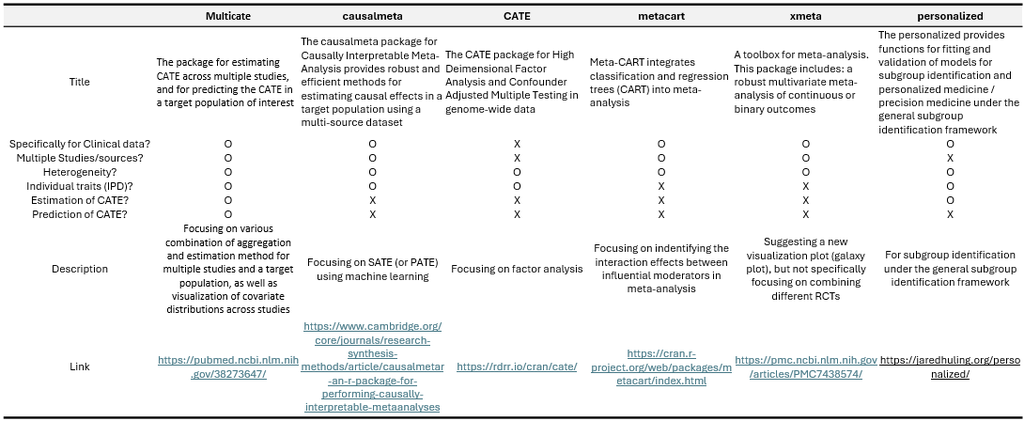

A comparison table of R packages related to estimate CATE or heterogeneity

Compared to other packages that more focus primarily on meta-analysis, our package, `mulicate` is unique in that it is specially designed to estimate Conditional Average Treatment Effects (CATE) by combining multiple RCTs and predict CATEs in a target population of interest. The aim of this package is to use this package to make informed decisions on which treatment may be preferable for the given covariate profile. To our knowledge, no other R package currently supports both estimation and prediction of CATEs specifically when combining RCTs with machine learning methods. A more detailed explanation of the methods, their contributions and limitations is provided in Brantner et al. (2024).[^3]

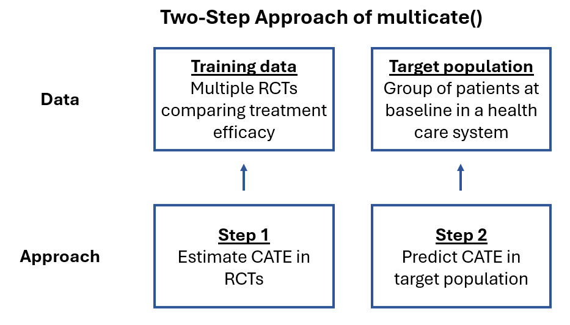